# Lecture5_assignment

# Central limit theorem: originating a Gaussian distribution from different probability distributions

Demonstrate the central limit theorem using the following original distributions: * Gaussian distribution (rnorm) with mean = 0 and SD = 20 * Uniform distribution (runif) with min/max values of 0 and 1 * A binomial distribution (rbinom) with p=0.1 * Chi-square distribution (rchisq) with 3 degrees of freedom

Generate the following samples and plot as a 3x2 layout: For each one of these, start by characterizing the probability distribution function by drawing 10,000 random samples. Plot the resulting distributions as a histogram. The code should be something like this:

```
draw 10,000 samples from distribution
plot vector_of_samples as histogram
```

```r
#Gaussian:

par(mfcol=c(3,2))

gauss_plot2 <- rnorm(10000, mean =0, sd =20)
hist(gauss_plot2, main ="Gaussian")

#Uniform:
uniform <- runif(10000, min=0, max=1)
hist(uniform, main ="Uniform")
```

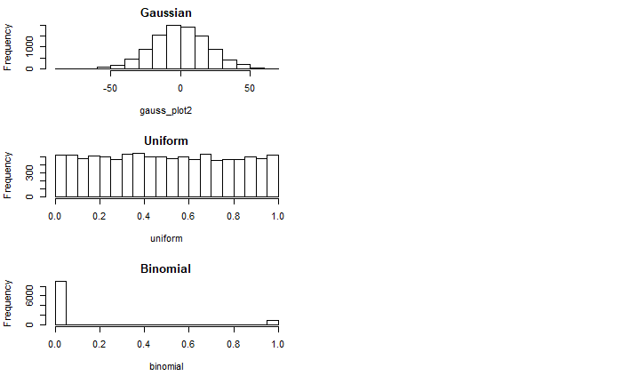

```r
#Binomial:
binomial <- rbinom(10000,size=1, p=0.1 )
hist(binomial, main ="Binomial")

#Chi square:
chisq <- rchisq(10000,3)
hist(chisq, main = "Chi-square")
```

[output not shown]

Then, use a ‘for’ loop to generate 10,000 random drawings of 25 samples each and calculate the mean for each one of these. Plot the resulting distribution of means.

The code should be something like this:

```
for 10,000 iterations
  draw 10 samples from distribution
  save mean in vector_of_means
end
plot vector_of_means as histogram
```

```r
#do the same thing as above:
par(mfcol=c(3,2))


draws1 = gauss_plot2
draws1 = matrix(draws1, 25)
drawmeans1 = apply(draws1, 2, mean)
hist(drawmeans1, main ="Gaussian mean 25 samples")

draws2 = uniform
draws2 = matrix(draws2, 25)
drawmeans2 = apply(draws2, 2, mean)
hist(drawmeans2, main ="Uniform means")
```

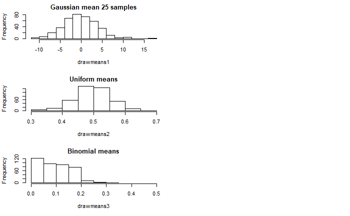

```r
draws3 = binomial
draws3 = matrix(draws3, 25)
drawmeans3 = apply(draws3, 2, mean)
hist(drawmeans3, main ="Binomial means", xlim= c(0,0.5))

draws4 = chisq
draws4 = matrix(draws4, 25)
drawmeans4 = apply(draws4, 2, mean)
hist(drawmeans4, main ="Chi-square means")
```

[output not shown]

```r
#not sure if this method actually works
```

# Central limit theorem: dependency on sample size (OPTIONAL)

The CLT states that the distribution of sample means approximates a normal distribution as the sample size becomes larger. Test this directly: starting with a uniform distribution, plot (as histograms) the distribution of the means from drawing 20, 100 and 5000 samples.

Plotting the vectors of means is useful, but you may need to formally test for normality before you embark on statistical inference using parametric testing. The Shapiro-Wilks test is a statistical test that allows testing for normality in a vector of values. Use it (shapiro.test()) to test whether your samples are normally distributed (p<0.05 means they are).

You can do this easily iterating over the different sample sizes using a ‘for’ loop. Here’s some pseudo-code to get you started:

```
define sample_sizes
for sample in sample_size
  draw n_of_samples from distribution
  plot n_of_samples as histogram
  shapiro_test n_of_samples
end
```